# NNT

> [The Number Needed to Treat (NNT) is the number of patients you need to treat to prevent one additional bad outcome (death, stroke, etc.).](https://www.cebm.ox.ac.uk/resources/ebm-tools/number-needed-to-treat-nnt)

## NNT values are not plausible?

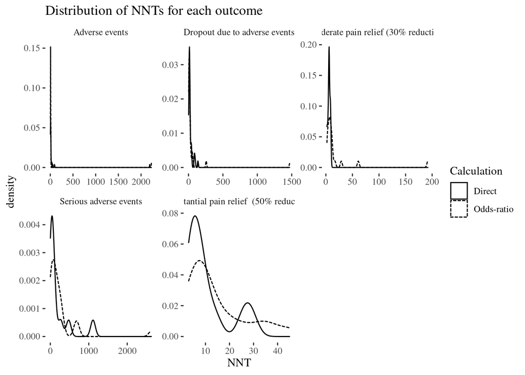

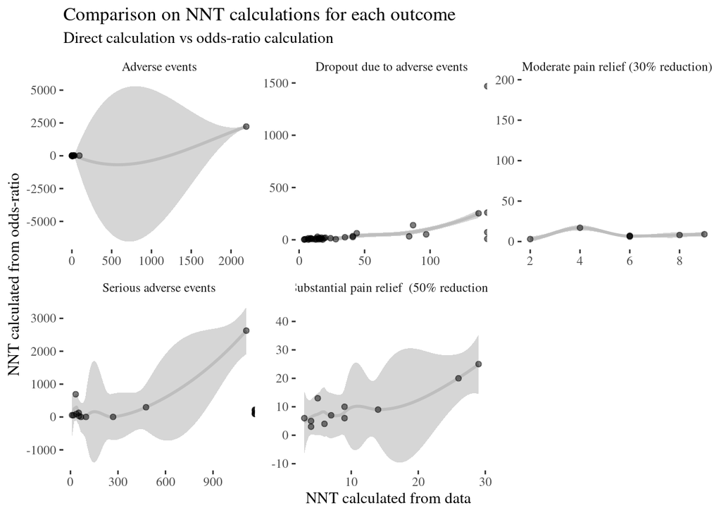

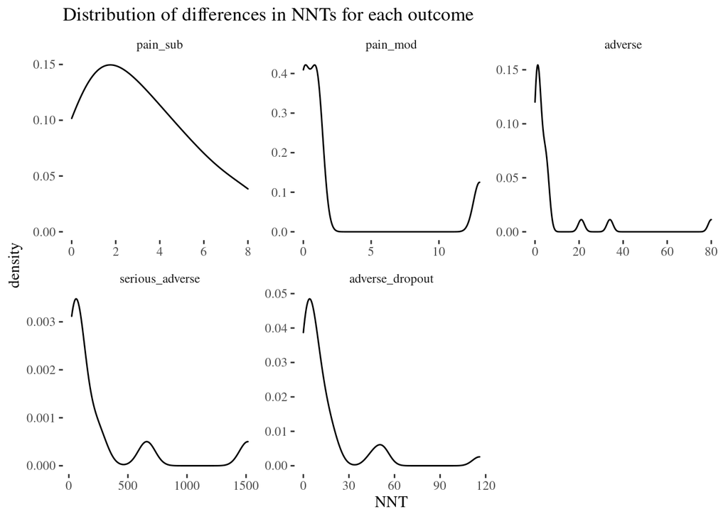

Random sample of 10 NNT calculations

For duloxetine, milnacipran, amitriptyline

| Outcome | Timepoint | Intervention | NNT calculated from data | NNT calculated from odds-ratio | Difference of NNTs | outcome_label |
| --- | --- | --- | --- | --- | --- | --- |
| serious_adverse | post_int | milnacipran | 1110 | 2626 | 1516 | Serious adverse events |
| pain_sub | post_int | milnacipran | 9 | 10 | 1 | Substantial pain relief (50% reduction) |
| pain_sub | post_int | duloxetine | 7 | 7 | 0 | Substantial pain relief (50% reduction) |
| adverse | post_int | milnacipran | 10 | 8 | 2 | Adverse events |
| adverse_dropout | post_int | milnacipran | 9 | 14 | 5 | Dropout due to adverse events |
| pain_sub | post_int | amitriptyline | NA | 9 | NA | Substantial pain relief (50% reduction) |
| adverse | post_int | duloxetine | 9 | 8 | 1 | Adverse events |
| serious_adverse | post_int | amitriptyline | 66 | 2 | 64 | Serious adverse events |
| adverse_dropout | post_int | duloxetine | 15 | 15 | 0 | Dropout due to adverse events |
| pain_mod | post_int | duloxetine | 6 | 7 | 1 | Moderate pain relief (30% reduction) |

## Calculating from the raw data

One way to calculate NNT is to compare the rates in the analysis data using the Absolute Risk Reduction ([ARR](https://www.cebm.ox.ac.uk/resources/ebm-tools/number-needed-to-treat-nnt)).

$$\text{NNT} := 1/\text{Absolute risk reduction} \\
= 1 / [{\text{Control event rate} - \text{Experimental event rate}]}\\$$

So, for the $i$th intervention, for the $k$th outcome,
$$\text{NNT_{ik}} := 1/[\frac{\Sigma_{ik} r^P_{ik}} {\Sigma_{ik} n^P_{ik}} -
\frac{\Sigma_{ik} r^T_{ik}} {\Sigma_{ik} n^T_{ik}}]$$
where $r^P_{ik}$ is the rate for the placebo group for the $i$th intervention and $k$th outcome; and $n^T_{ik}$ indicates the sample size of the treatment group for the same intervention and outcome.

> Gav, does the direction of improvement alter the order of this calculation?

## Calculating using odds-ratios

[Cochrane example](https://handbook-5-1.cochrane.org/chapter_12/12_5_4_3_computing_absolute_risk_reduction_or_nnt_from_an_odds.htm)

$$\text{NNT} := 1/|ACR - (OR \times ACR) / (1 - ACR + OR \times ACR)|$$
where $ACR$ is the assumed control risk.

There are a few ways to calculate ACR:

- from model
- from baseline data
- from all data

We are currently calculating ACR from overall rate for the placebo group across all data because baseline data is not available for most of our outcomes.

### Checking function works as it should

```r
library(adpain)

or <- 0.73

acr <- 0.3

nnt_cochrane <-
  ceiling(16.2)

# calculate
nnt_adpain <- nnt(or, acr)

# results
nnt_cochrane
```

```
## [1] 17
```

```r
nnt_adpain
```

```
## [1] 17
```

```r
# compare
nnt_adpain == nnt_cochrane
```

```
## [1] TRUE
```

## Questions

- Does direction of improvement matter for calculation? i.e., NNTH and NNTB (harm vs benefit)?
- In one of the resources there are two equations?
- Do we wish to see big numbers for one and small for the other direction?
- Should this be approached by examining how ACR is calculated?